# Zine

### Grooves Research Ideas Data

© 2025 GRID Magazine

### GRID Magazine Issue 1

[figure not shown]

Agnes Martin, Untitled, 1973

# The Light That Shines

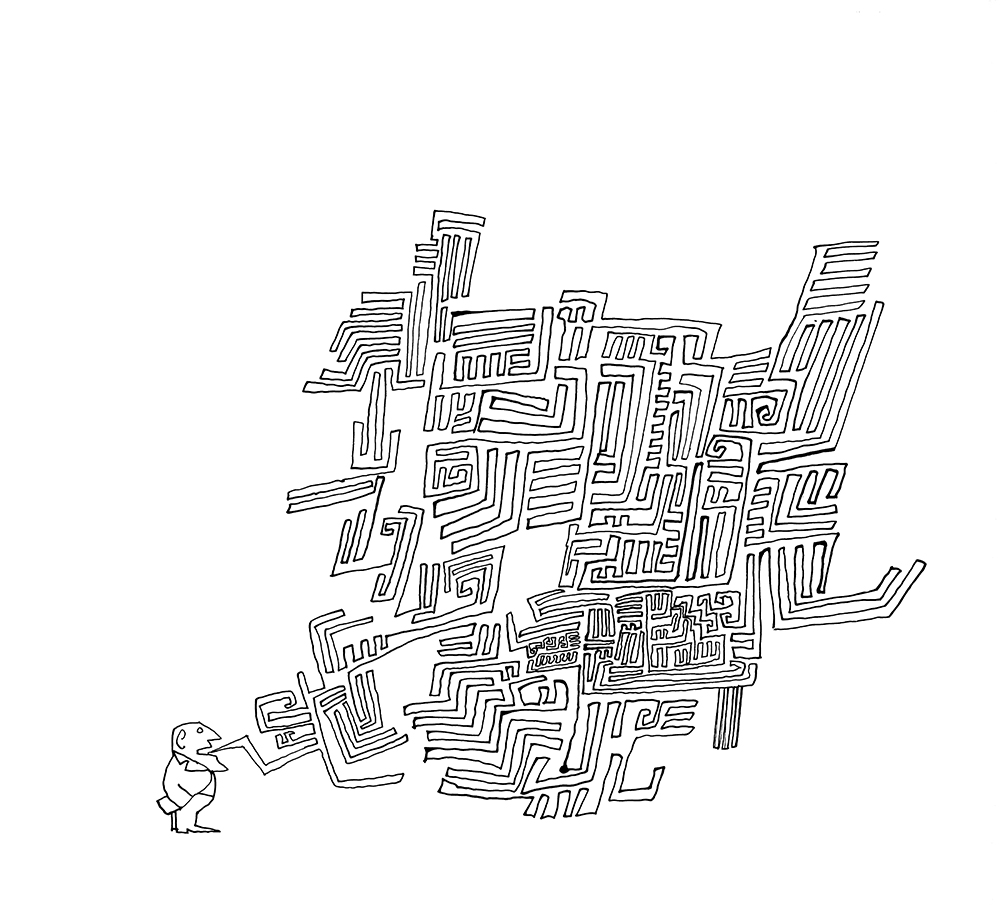

**GRID** is grooves, research, ideas, data  
**GRID** is the anti-dystopian's favorite rag  
**GRID** to navigate our complex modern existence  
**GRID** to grow your optimism and sense of grace

### 10 Triumphant Songs

Oppressive worlds inspire triumphant sounds. These 10 songs get us through our days with deep emotion and explosive grooves. Some songs smack instantly, like Galaxy Band. Others burn slow for minutes, and minutes, like Isaac Hayes's masterful cover of Jimmy Webb's song popularized by the Rhinestone Cowboy, Glenn Campbell

🪩 🪩 🪩 **HANDS RAISED** 🪩 🪩 🪩

1. Reggio—The Light
2. Galaxy Band—Gosh
3. Solange—Losing You
4. Bob Dylan—No Time To Think
5. John David—On The Mountain ⛰
6. Josette Martial—Let's Be Winners
7. The Temper Trap—Sweet Disposition
8. Jerry Garcia Band—Rubin and Cherise
9. Phish—What's Going Through Your Mind
10. Isaac Hayes—By The Time I Get To Phoenix (18-minute version)

### How Many Times Did Trey Say "Mind"?

[figure not shown]

### What's Going Through Your Mind

# mind mind mind mind mind mind mind mind mind mind mind mind mind mind mind mind mind mind mind mind mind mind mind mind mind mind mind mind mind mind mind mind mind mind mind mind mind mind mind mind mind mind mind mind mind mind mind mind mind mind mind mind mind mind mind mind mind mind mind mind

### Inventing the Disco Ball

The patent application for the disco ball, or "myriad reflector," was filed in 1916 by Louis Bernard Woeste of Kentucky. Woeste wrote his invention's aim is "to produce a myriad reflector reflecting surfaces, the same to be arranged in such a manner that the several reflections shall be projected at varying angles, the device itself being arranged so that it may be rotated or otherwise moved so that the reflections may [produce a] spectacular effect." The illustration accompanying Woeste's application is below. Next time you find yourself mesmerized by a disco ball, thank Louis Bernard Woeste's spectacular aesthetic

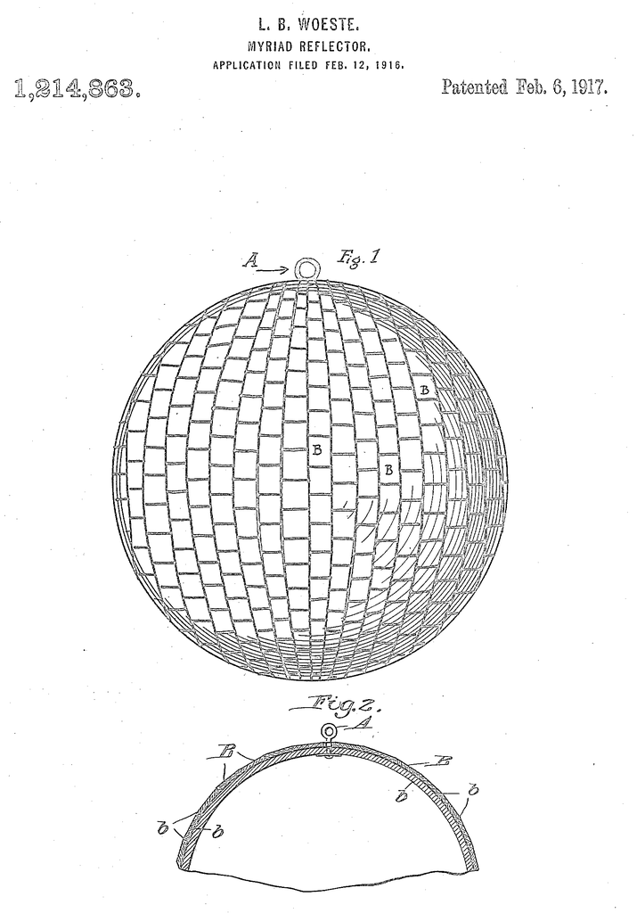